# Chicago Homicide Geography: A Spatial Analysis

- Show All Code
- Hide All Code
- View Source

Examining patterns in violent crime and arrest rates across neighborhoods

Author

Yosup Shin

Published

September 2, 2026

## Project Overview

This project analyzes the spatial distribution of homicides in Chicago over the past decade (2015–2025), combining crime incident data with census tract boundaries to uncover neighborhood-level patterns. The analysis examines:

1. **Where homicides are concentrated** — which neighborhoods bear the heaviest burden
2. **Arrest rate disparities** — whether enforcement outcomes vary geographically
3. **Socioeconomic context** — linking crime patterns to poverty, income, and education

**Data sources:**

- [Chicago Police Department — Crimes 2001 to Present](https://data.cityofchicago.org/Public-Safety/Crimes-2001-to-Present/ijzp-q8t2)
- Chicago census tract boundaries (City of Chicago Data Portal)
- U.S. Census Bureau — American Community Survey 5-Year Estimates (2019)

## Setup

**Load libraries and configure environment**

```r
library(tidyverse)
library(readxl)
library(sf)
library(lubridate)
library(tidycensus)
library(httr)
library(jsonlite)
library(scales)
library(dotenv)

# Load Census API key from .env file
load_dot_env()
census_api_key(Sys.getenv("CENSUS_API_KEY"), install = FALSE, overwrite = TRUE)
```

## Data Loading & Preparation

### Chicago Crime Data

The full “Crimes 2001 to Present” dataset holds over 8 million records. Rather than download the whole ~2 GB file, this analysis pulls **only homicides from the last 10 years** directly from the Chicago Data Portal (Socrata API, dataset `ijzp-q8t2`), so the report is reproducible from a clean clone. If a local copy of the bulk CSV is present in `data/`, it is used instead.

**Load Chicago homicide data (Socrata API, or local bulk CSV if present)**

```r
local_csv <- "data/Crimes_-_2001_to_Present_20251020.csv"

if (file.exists(local_csv)) {
  crimes <- read_csv(
    local_csv,
    col_types = cols(Longitude = col_character(), Latitude = col_character())
  )
} else {
  cutoff <- format(Sys.Date() - lubridate::years(10), "%Y-%m-%dT00:00:00")
  where  <- utils::URLencode(
    sprintf("primary_type='HOMICIDE' AND date > '%s'", cutoff),
    reserved = TRUE
  )
  api_url <- sprintf(
    "https://data.cityofchicago.org/resource/ijzp-q8t2.csv?$where=%s&$limit=100000",
    where
  )
  crimes <- read_csv(api_url, show_col_types = FALSE)
}

# Standardize column names (lowercase, underscores)
names(crimes) <- names(crimes) |>
  str_replace_all("\\s", "_") |>
  str_to_lower()
```

### Filtering to Recent Homicides

**Filter to homicides from the last 10 years with valid coordinates**

```r
crimes_lim <- crimes |>
  # `date` is "MM/DD/YYYY hh:mm:ss AM/PM" in the bulk CSV and ISO 8601 from the API
  mutate(
    date = date |>
      str_replace("T", " ") |>
      str_remove("\\.\\d+$") |>
      lubridate::parse_date_time(orders = c("m/d/Y I:M:S p", "Y-m-d H:M:S"))
  ) |>
  filter(
    date >= today(tz = "") - years(10),
    !is.na(latitude),
    !is.na(longitude),
    primary_type == "HOMICIDE"
  )

cat("Total homicides (past 10 years):", nrow(crimes_lim))
```

```
Total homicides (past 10 years): 6370
```

## Spatial Analysis

### Converting to Geographic Points

Each crime incident is converted to a point geometry using longitude/latitude coordinates (WGS 84 / EPSG:4326).

**Convert crime data to sf point geometry**

```r
crimes_lim <- crimes_lim |>
  st_as_sf(
    coords = c("longitude", "latitude"),
    crs = 4326,
    remove = FALSE
  )
```

### Load Census Tract Boundaries

We load the Chicago census tract shapefile now so it can serve as a basemap for the point map below, and for the tract-level aggregation that follows.

**Load Chicago census tract shapefile**

```r
chicago_tracts <- st_read(
  "data/geo_export_74935939-21bb-469e-8d1f-e14171c59c67.shp",
  quiet = TRUE
) |>
  select(geoid10, geometry) |>
  st_transform(crs = 4326)
```

### Homicide Locations by Arrest Outcome

This map shows every homicide incident, color-coded by whether an arrest was made. Red = no arrest; blue = arrest.

**Point map: homicides by arrest status**

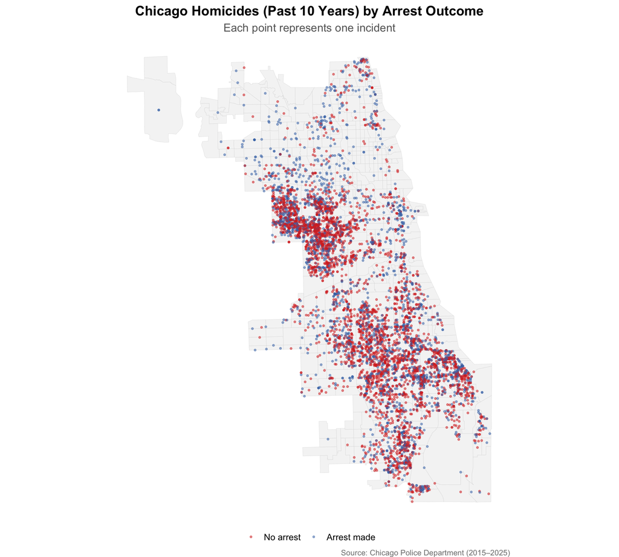

Figure 1: Geographic distribution of homicides colored by arrest outcome

```r
crimes_lim |>
  ggplot() +
  geom_sf(data = chicago_tracts, fill = "grey96", color = "grey85", linewidth = 0.1) +
  geom_sf(aes(color = arrest), alpha = 0.5, size = 0.8) +
  scale_color_manual(
    values = c(
      "FALSE" = "#d73027",
      "TRUE" = "#4575b4"
    ),
    labels = c("No arrest", "Arrest made"),
    name = NULL
  ) +
  labs(
    title = "Chicago Homicides (Past 10 Years) by Arrest Outcome",
    subtitle = "Each point represents one incident",
    caption = "Source: Chicago Police Department (2015–2025)"
  ) +
  theme_void(base_size = 13) +
  theme(
    plot.title = element_text(face = "bold", hjust = 0.5),
    plot.subtitle = element_text(color = "grey40", hjust = 0.5),
    plot.caption = element_text(color = "grey50", size = 9),
    legend.position = "bottom"
  )
```

> **Observation:** Even at first glance, homicides cluster heavily on the South and West sides, with notably lower density in the Loop and North Side neighborhoods.

## Census Tract Aggregation

To analyze neighborhood-level patterns, we aggregate homicides by census tract, using the boundaries loaded above.

### Spatial Join: Crimes to Tracts

**Join homicide points to census tracts**

```r
# Join crimes to tracts based on spatial containment
crimes_by_tract <- st_join(crimes_lim, chicago_tracts, join = st_within)

# Aggregate: count homicides per tract
tract_summary <- crimes_by_tract |>
  st_drop_geometry() |>
  group_by(geoid10) |>
  summarize(
    homicide_count = n(),
    arrests_made = sum(arrest == TRUE, na.rm = TRUE)
  ) |>
  mutate(arrest_rate = arrests_made / homicide_count)

# Merge back with tract geometries
chicago_analysis <- chicago_tracts |>
  left_join(tract_summary, by = "geoid10")
```

## Visualizing Spatial Patterns

### Homicide Count by Census Tract

This choropleth reveals which neighborhoods experience the highest absolute number of homicides.

**Choropleth map: homicide count**

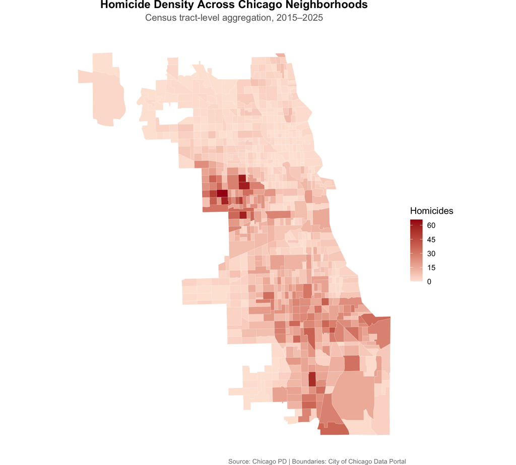

Figure 2: Homicide counts by census tract (darker = more homicides)

```r
chicago_analysis |>
  mutate(homicide_count = tidyr::replace_na(homicide_count, 0)) |>
  ggplot() +
  geom_sf(aes(fill = homicide_count), color = "white", linewidth = 0.05) +
  scale_fill_gradient(
    low = "#fee5d9",
    high = "#a50f15",
    name = "Homicides",
    breaks = seq(0, 60, by = 15),
    labels = comma
  ) +
  labs(
    title = "Homicide Density Across Chicago Neighborhoods",
    subtitle = "Census tract-level aggregation, 2015–2025",
    caption = "Source: Chicago PD | Boundaries: City of Chicago Data Portal"
  ) +
  theme_void(base_size = 13) +
  theme(
    plot.title = element_text(face = "bold", hjust = 0.5, margin = margin(b = 5)),
    plot.subtitle = element_text(color = "grey40", hjust = 0.5, margin = margin(b = 15)),
    plot.caption = element_text(color = "grey50", size = 9, hjust = 1),
    legend.position = "right"
  )
```

> **Key Finding:** Homicides are highly concentrated. A small number of South and West Side tracts account for a disproportionate share of incidents, while large swaths of the North Side report zero or near-zero homicides.

### Arrest Rate by Census Tract

This map shows the *proportion* of homicides that result in an arrest — a measure of clearance rate disparities.

**Choropleth map: arrest rate**

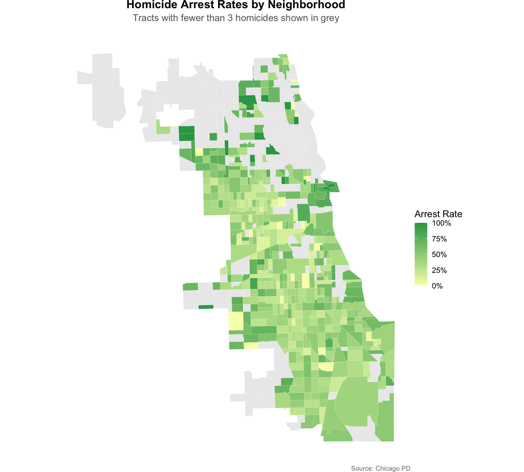

Figure 3: Arrest rates by census tract (darker = higher clearance rate)

```r
chicago_analysis |>
  # keep every tract in the map, but only shade arrest rate where the tract has
  # enough homicides (>= 3) for the rate to be meaningful; the rest render grey
  mutate(arrest_rate = if_else(coalesce(homicide_count, 0L) >= 3, arrest_rate, NA_real_)) |>
  ggplot() +
  geom_sf(aes(fill = arrest_rate), color = "white", linewidth = 0.05) +
  scale_fill_gradient(
    low = "#f7fcb9",
    high = "#31a354",
    name = "Arrest Rate",
    labels = percent_format(accuracy = 1),
    na.value = "grey92"
  ) +
  labs(
    title = "Homicide Arrest Rates by Neighborhood",
    subtitle = "Tracts with fewer than 3 homicides shown in grey",
    caption = "Source: Chicago PD"
  ) +
  theme_void(base_size = 13) +
  theme(
    plot.title = element_text(face = "bold", hjust = 0.5, margin = margin(b = 5)),
    plot.subtitle = element_text(color = "grey40", hjust = 0.5, margin = margin(b = 15)),
    plot.caption = element_text(color = "grey50", size = 9, hjust = 1),
    legend.position = "right"
  )
```

> **Interpretation:** If arrest rates vary substantially by neighborhood, it suggests potential disparities in investigative resources or community cooperation with law enforcement.

## Socioeconomic Context from Census Data

To understand *why* homicides concentrate in certain areas, we retrieve neighborhood-level socioeconomic indicators from the Census Bureau.

### Retrieve ACS Data via API

**Fetch median income, education, and poverty from Census API**

```r
census_key <- Sys.getenv("CENSUS_API_KEY")
if (!nzchar(census_key)) {
  stop("CENSUS_API_KEY is not set. Get a free key at https://api.census.gov/data/key_signup.html, ",
       "click the activation link in the confirmation email, then put it in a .env file: ",
       "CENSUS_API_KEY=your_key")
}

# Construct API query for Cook County (Chicago) census tracts
api_url <- paste0(
  "https://api.census.gov/data/2019/acs/acs5",
  "?get=NAME,B19013_001E,B29002_007E,B29003_002E",
  "&for=tract:*",
  "&in=state:17&in=county:031",
  "&key=", census_key
)

response <- GET(url = api_url)
raw_data <- content(response, as = "text", encoding = "UTF-8")

# The Census API redirects an unactivated / invalid key to an HTML error page,
# so guard the JSON parse and fall back to tidycensus for a transient hiccup.
census_data <- tryCatch({
  if (http_error(response) || !startsWith(trimws(raw_data), "[")) {
    stop("Census API did not return JSON (HTTP ", status_code(response),
         "). Most often this means the API key has not been activated yet.")
  }
  dm  <- fromJSON(raw_data)
  out <- as_tibble(dm[2:nrow(dm), ], .name_repair = "minimal")
  names(out) <- dm[1, ]
  out |>
    rename(
      tract_name      = NAME,
      median_income   = B19013_001E,
      bachelor_degree = B29002_007E,
      poverty_count   = B29003_002E
    ) |>
    mutate(
      across(c(median_income, bachelor_degree, poverty_count), as.numeric),
      geoid10 = paste0(state, county, tract)
    )
}, error = function(e) {
  message("Raw API call failed (", conditionMessage(e), "); trying tidycensus::get_acs()...")
  tryCatch(
    get_acs(
      geography = "tract", state = "IL", county = "Cook",
      year = 2019, survey = "acs5", output = "wide",
      variables = c(median_income = "B19013_001",
                    bachelor_degree = "B29002_007",
                    poverty_count = "B29003_002")
    ) |>
      transmute(
        geoid10         = GEOID,
        tract_name      = NAME,
        median_income   = median_incomeE,
        bachelor_degree = bachelor_degreeE,
        poverty_count   = poverty_countE
      ),
    error = function(e2) stop(
      "Both the raw Census API and tidycensus failed. This almost always means the ",
      "CENSUS_API_KEY has not been activated yet: check your email from the U.S. Census ",
      "Bureau and click the activation link, wait a few minutes, then re-render. (",
      conditionMessage(e2), ")"
    )
  )
})

glimpse(census_data)
```

```
Rows: 1,319
Columns: 8
$ tract_name      <chr> "Census Tract 6302, Cook County, Illinois", "Census Tr…
$ median_income   <dbl> 37422, 47000, 46033, 45294, 24507, 71438, 69472, 11550…
$ bachelor_degree <dbl> 92, 407, 225, 462, 0, 592, 990, 575, 1250, 936, 1457, …
$ poverty_count   <dbl> 65, 578, 171, 298, 368, 203, 220, 15, 144, 117, 366, 7…
$ state           <chr> "17", "17", "17", "17", "17", "17", "17", "17", "17", …
$ county          <chr> "031", "031", "031", "031", "031", "031", "031", "031"…
$ tract           <chr> "630200", "580700", "590600", "600700", "611900", "804…
$ geoid10         <chr> "17031630200", "17031580700", "17031590600", "17031600…
```

### Compare API vs. tidycensus

For validation, we also pull the same variables using `tidycensus` and confirm row counts match.

**Cross-validate API results with tidycensus package**

```r
census_tidycensus <- get_acs(
  geography = "tract",
  state = "IL",
  county = "Cook",
  year = 2019,
  survey = "acs5",
  variables = c(
    median_income = "B19013_001",
    bachelor_degree = "B29002_007",
    poverty_count = "B29003_002"
  ),
  output = "wide"
)

# Validation check
cat("API rows:", nrow(census_data), "\n")
```

```
API rows: 1319
```

**Cross-validate API results with tidycensus package**

```r
cat("tidycensus rows:", length(unique(census_tidycensus$GEOID)), "\n")
```

```
tidycensus rows: 1319
```

**Cross-validate API results with tidycensus package**

```r
cat("Match:", nrow(census_data) == length(unique(census_tidycensus$GEOID)))
```

```
Match: TRUE
```

> **Note:** Both methods return the same number of census tracts, confirming the API request was correctly structured.

## Linking Crime and Socioeconomic Data

**Join census demographics to crime aggregates**

```r
# Merge census data with crime summary
chicago_full <- chicago_analysis |>
  left_join(
    census_data |> select(geoid10, median_income, bachelor_degree, poverty_count),
    by = "geoid10"
  )

# Preview
chicago_full |>
  st_drop_geometry() |>
  filter(!is.na(homicide_count), !is.na(median_income)) |>
  select(geoid10, homicide_count, arrest_rate, median_income, poverty_count) |>
  head(10)
```

```
       geoid10 homicide_count arrest_rate median_income poverty_count
1  17031842400             37   0.4594595         47669           481
2  17031840300              9   0.5555556         50607           229
3  17031841100             11   0.6363636         35723          1267
4  17031841200             17   0.1176471         45700           413
5  17031839000              1   1.0000000        105094          1178
6  17031838200              1   0.0000000         61458           123
7  17031650301              3   0.6666667         60802           112
8  17031530503             26   0.5000000         44056           831
9  17031760803              1   1.0000000         44918           327
10 17031030604              1   1.0000000         47500           527
```

## Exploratory Correlation: Income vs. Homicide Rate

**Scatter plot: income vs. crime**

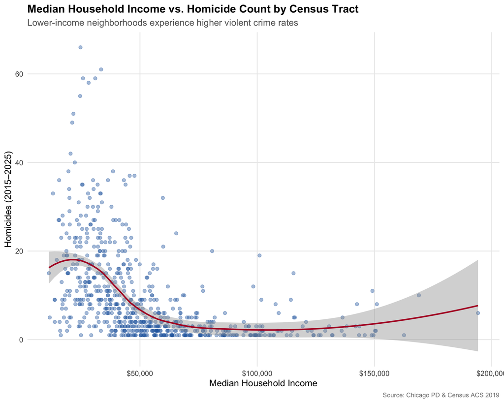

Figure 4: Relationship between neighborhood median income and homicide count

```r
chicago_full |>
  st_drop_geometry() |>
  filter(!is.na(homicide_count), !is.na(median_income), median_income > 0) |>
  ggplot(aes(x = median_income, y = homicide_count)) +
  geom_point(alpha = 0.4, color = "#2166ac", size = 2) +
  geom_smooth(method = "loess", se = TRUE, color = "#b2182b", linewidth = 1) +
  scale_x_continuous(labels = label_dollar(scale = 1)) +
  scale_y_continuous(labels = comma) +
  labs(
    title = "Median Household Income vs. Homicide Count by Census Tract",
    subtitle = "Lower-income neighborhoods experience higher violent crime rates",
    x = "Median Household Income",
    y = "Homicides (2015–2025)",
    caption = "Source: Chicago PD & Census ACS 2019"
  ) +
  theme_minimal(base_size = 13) +
  theme(
    plot.title = element_text(face = "bold"),
    plot.subtitle = element_text(color = "grey40"),
    plot.caption = element_text(color = "grey50", size = 9),
    panel.grid.minor = element_blank()
  )
```

> **Takeaway:** There’s a clear negative relationship — tracts with lower median incomes tend to have higher homicide counts. This aligns with extensive criminology literature linking poverty to violent crime.

## Summary & Policy Implications

| Question | Finding |
| --- | --- |
| **Where are homicides concentrated?** | South and West Side neighborhoods bear a disproportionate burden |
| **Do arrest rates vary geographically?** | Preliminary evidence suggests variation, warranting deeper investigation |
| **Does income predict crime?** | Strong negative correlation — poorer tracts have higher homicide rates |

**Next steps for deeper analysis:**

- **Multivariate regression:** Control for population density, unemployment, and proximity to transit
- **Temporal trends:** Has the geographic concentration increased or decreased over time?
- **Arrest disparity analysis:** Are lower arrest rates in certain neighborhoods due to resource allocation or community factors?
- **Policy linkage:** Map police district boundaries and budget allocations to test whether resource distribution aligns with crime burden

**Broader context:** This analysis supports evidence-based resource allocation — targeting violence intervention programs, community investment, and investigative capacity to the neighborhoods that need them most.

*Analysis by Yosup Shin | Data: Chicago PD, City of Chicago Data Portal, U.S. Census Bureau*